# SWOMSE User Manual

Adrian Hordyk

November 2019

# 1 Introduction

The `SWOMSE` R package has been developed to conduct a management strategy evaluation (MSE) for the Atlantic swordfish fishery.

The package includes a collection of swordfish operating models (OMs), a swordfish data object, and management procedures (MPs) that can be evaluated with closed-loop simulation testing, and applied to the data object for management advice.

This document describes the contents `SWOMSE` R package, and illustrates how the package can be used to conduct the MSE and examine the results.

## 1.1 Installing the Package

The `devtools` package is required to install the `SWOMSE` package. Install the `devtools` package with:

```r
install.packages('devtools')
```

The `SWOMSE` package can be installed from this GitHub repository using the `devtools` package:

```r
# install.packages("devtools")
devtools::install_github("ICCAT/nswo-mse", auth_token='your_personal_access_token')
```

Note that as this repository is private, you will need to provide a personal access token to download and install from GitHub. See [here](https://help.github.com/en/github/authenticating-to-github/creating-a-personal-access-token-for-the-command-line) for information on creating a personal access token.

Alternatively, you can clone the repository on your machine and build and install the package locally with RStudio.

Once installed, the package can be loaded into the current R session:

```r
library(SWOMSE)
```

# 2 The `SWOMSE` R Package

The `SWOMSE` package depends on the [`DLMtool`](https://cran.r-project.org/package=DLMtool) and [`MSEtool`](https://cran.r-project.org/package=MSEtool) R packages. Extensive help documentation is available for both packages by typing the following commands in the R console:

```r
DLMtool::userguide()
MSEtool::userguide()
```

However, the `SWOMSE` package is designed to be self-contained and it is not be necessary to be familiar with the `DLMtool` or `MSEtool` R packages to run the MSE using the `SWOMSE` package.

This user guide is included as a vignette in the `SWOMSE` package and can be accessed with:

```r
SWO_userguide()
```

The `SWOMSE` package follows the same object-oriented programming framework as `DLMtool` and `MSEtool`. This means that all objects and functions in the package are defined as specific classes that determines how the objects and treated.

There are three primary object classes that are used to run the MSE: `OM`, `Data`, and `MP`. These are described in the following sections.

## 2.1 Operating Models

Operating models are class `OM` and contain all parameters relating to the stock and fleet dynamics, as well as the observation and implementation processes.

There are 175 objects of class `OM` included in the `SWOMSE` package. The available OMs can be displayed using the `avail` command (here we just display the first 10):

```r
OMs <- avail("OM")
OMs[1:10]
```

```
#>  [1] "SWOM"         "OM_base_case" "OM_19"        "OM_20"
#>  [5] "OM_21"        "OM_22"        "OM_23"        "OM_24"
#>  [9] "OM_25"        "OM_26"
```

The OMs included in the `SWOMSE` package have been constructed from the SS3 base case assessment and the converged SS3 assessments from the grid of uncertainties.

The first OM `SWOM` includes all of the SS3 assessments: the base case and the 173 converged OMs from the uncertainty grid. Each of the SS3 assessments is included as a separate simulation in the `SWOM` object.

The other 174 OMs in the `SWOMSE` package are the individual SS3 assessment OMs, including the base case assessment (`OM_base_case`) and the converged assessments from the uncertainty grid (e.g., `OM_19` for assessment 19 - the first SS3 converged assessment, `OM_20` for assessment 20, etc.)

The `SWOM` contains 174 simulations, corresponding to the base case OM, and the 173 OMs from the uncertainty grid.

The combined OM `SWOM` is used throughout this vignette. However, the analysis described here can be reproduced for any of the operating models be replacing `SWOM` with the name of the individual OM, for example, `OM_base_case` or `OM_19`.

### 2.1.1 Examining the OM Object

The contents of the operating model can be examined graphically using the `plot` function:

```r
plot(SWOM)
```

This function generates a HTML file with histograms of all parameters in the operating model, as well as time-series plots of the historical population dynamics that are simulated by the model.

For convenience, the OM plot file is included in the package and can be viewed with:

```r
browseURL(file.path(system.file(package="SWOMSE"), "OM.html"))
```

## 2.2 Data Object

Objects of class `Data` contain fishery data that is used by management procedures, both within the MSE simulations and to provide real management advice.

### 2.2.1 Built-in Data Object

The `SWOMSE` package contains one object of class Data, which is populated with data from the swordfish fishery:

```r
avail("Data")
```

```
#> [1] "SWOData"
```

Objects of class `Data` can be plotted using the `summary` function:

```r
summary(SWOData, wait=FALSE)
```

```
#> Plotting Time-Series
#> Plotting Catch-at-Length
#> Plot 1 of 2
```

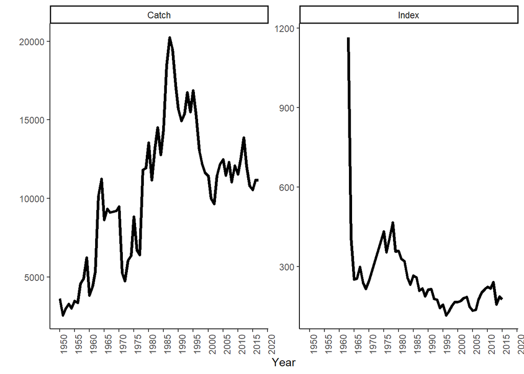

```
#> Plot 2 of 2
```

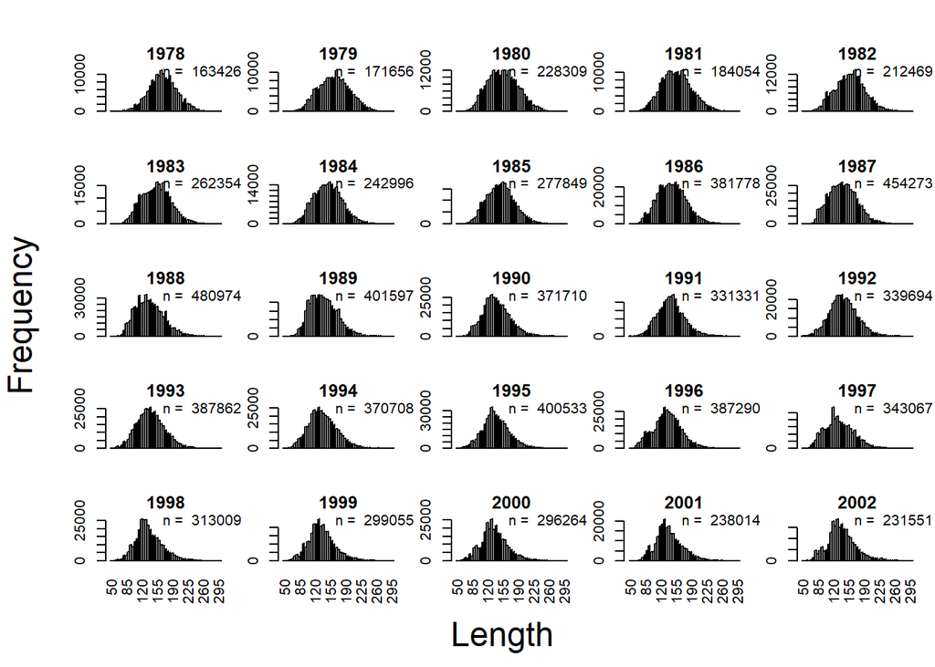

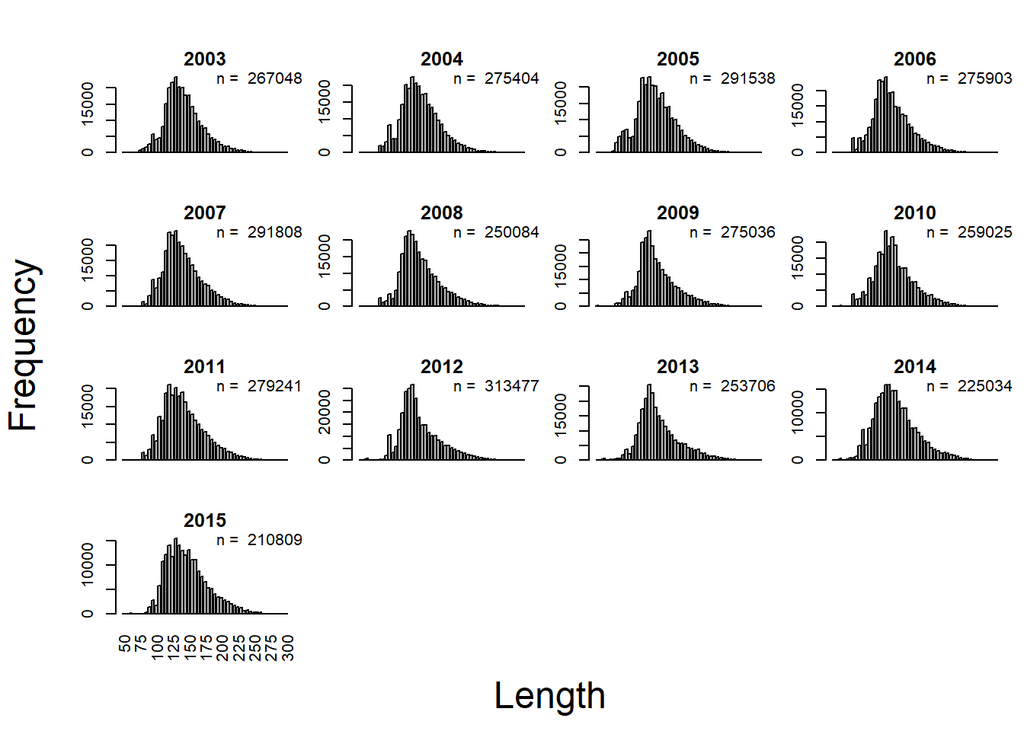

The data can be displayed by accessing the relevant slot in the `Data` object. For example, the catch data and annual CVs are stored in the `Cat` and `CV_Cat` slots:

```r
SWOData@Cat[1,]
```

```
#>  [1]  3646  2581  2993  3303  3034  3502  3358  4578  4904  6232  3828
#> [12]  4381  5342 10190 11258  8652  9349  9107  9172  9203  9495  5266
#> [23]  4766  6074  6362  8839  6696  6409 11827 11937 13558 11180 13215
#> [34] 14527 12791 14383 18486 20236 19513 17250 15672 14934 15394 16738
#> [45] 15501 16872 15222 13025 12223 11621 11452 10010  9654 11443 12176
#> [56] 12480 11471 12302 11050 12082 11553 12522 13873 12068 10811 10549
#> [67] 11172 11172
```

```r
SWOData@CV_Cat[1,]
```

```
#>  [1] 0.2 0.2 0.2 0.2 0.2 0.2 0.2 0.2 0.2 0.2 0.2 0.2 0.2 0.2 0.2 0.2 0.2
#> [18] 0.2 0.2 0.2 0.2 0.2 0.2 0.2 0.2 0.2 0.2 0.2 0.2 0.2 0.2 0.2 0.2 0.2
#> [35] 0.2 0.2 0.2 0.2 0.2 0.2 0.2 0.2 0.2 0.2 0.2 0.2 0.2 0.2 0.2 0.2 0.2
#> [52] 0.2 0.2 0.2 0.2 0.2 0.2 0.2 0.2 0.2 0.2 0.2 0.2 0.2 0.2 0.2 0.2 0.2
```

Note that a default value of catch CV of 0.2 has been assumed.

The index data and annual CVs are stored in `Ind` and `CV_Ind`:

```r
DF <- data.frame(Year=SWOData@Year, Index=SWOData@Ind[1,], CV=SWOData@CV_Ind[1,])
head(DF, 20)
```

```
#>    Year  Index        CV
#> 1  1950     NA        NA
#> 2  1951     NA        NA
#> 3  1952     NA        NA
#> 4  1953     NA        NA
#> 5  1954     NA        NA
#> 6  1955     NA        NA
#> 7  1956     NA        NA
#> 8  1957     NA        NA
#> 9  1958     NA        NA
#> 10 1959     NA        NA
#> 11 1960     NA        NA
#> 12 1961     NA        NA
#> 13 1962     NA        NA
#> 14 1963 1164.2 0.3533291
#> 15 1964  409.4 0.3491971
#> 16 1965  252.7 0.3484340
#> 17 1966  255.1 0.3477186
#> 18 1967  299.1 0.3471943
#> 19 1968  238.3 0.3514849
#> 20 1969  217.2 0.3474511
```

The `SWOData` object also contains 3 example additional indices in the `AddInd` slot that can be used in cases where management procedures require multiple indices:

For example, the first additional index is accessed by:

```r
DF <- data.frame(Year=SWOData@Year, Add.Index.1=SWOData@AddInd[1,1,], CV=SWOData@CV_AddInd[1,1,])
head(DF, 20)
```

```
#>    Year Add.Index.1   CV
#> 1  1950          NA   NA
#> 2  1951          NA   NA
#> 3  1952          NA   NA
#> 4  1953          NA   NA
#> 5  1954          NA   NA
#> 6  1955          NA   NA
#> 7  1956          NA   NA
#> 8  1957          NA   NA
#> 9  1958          NA   NA
#> 10 1959          NA   NA
#> 11 1960          NA   NA
#> 12 1961          NA   NA
#> 13 1962      109.27 0.19
#> 14 1963      201.92 0.07
#> 15 1964       79.73 0.06
#> 16 1965       55.55 0.06
#> 17 1966       58.74 0.05
#> 18 1967       78.04 0.05
#> 19 1968       54.03 0.05
#> 20 1969       51.12 0.05
```

Any number of additional indices can be added to the Data object.

### 2.2.2 Data Excel File

The swordfish data is stored in an Excel file which is included in the `SWOMSE` package.

The location of the Excel data file can be found using the following command:

```r
system.file(package="SWOMSE")
```

```
#> [1] "C:/~/R/win-library/3.6/SWOMSE"
```

The data in the Excel file can be modified and imported back into R using the `XL2Data` function.

For example, suppose we copied the Excel Data file from the system location found above using `system.file` to “C:/users/user/desktop”. We could then modify the data stored in the Excel file, or add additional data, and then re-import by typing:

```r
SWO_newData <- XL2Data('C:/users/users/desktop/SWO_Data.xlsx')
```

## 2.3 Management Procedures

Management procedures (functions of class `MP`) are applied to `Data` objects and return management recommendations.

MPs are applied in the MSE (i.e., to objects of class `Data` populated with data simulated from the operating model) and to the real fishery data (e.g., `SWOData`).

### 2.3.1 `SWOMSE` MPs

The `SWOMSE` package includes 4 very simple example MPs:

```r
avail("MP")
```

```
#> [1] "ConstC"   "Itarg1"   "AverageC" "Itarg2"
```

Help documentation for the MPs is found using the usual approach in R:

```r
?Itarg1
```

#### 2.3.1.1 `ConstC` MP

`ConstC` is a simple constant catch MP, which sets a fixed TAC for all future years at the current TAC. This MP has been included to provide an simple example of how MPs are constructed in the `SWOMSE` package.

We will step through the code for `ConstC` to explain how MPs work in the `SWOMSE` package.

All MPs must have at least the same three arguments as `ConstC`: `x`, `Data`, and `reps`:

```r
args(ConstC)
```

```
#> function (x, Data, reps = 100)
#> NULL
```

`x` is the position in a `Data` object. When applying an MP to real data, `x` is always 1, because there is only one set of real fishery data. In closed-loop simulation, the model generates `OM@nsim` simulated data sets, and `x` can be any value between 1 and `OM@nsim`.

The second argument `Data` is an object of class `Data`, such as the swordfish data object `SWOData`.

The third argument `reps` indicates the number of replicates or samples to produce each time the MP is run.

The code for `ConstC` is very simple:

```r
ConstC
```

```
#> function(x, Data, reps=100) {
#>   LastTAC <- Data@MPrec[x] # last TAC
#>   TAC <- rep(LastTAC, reps)
#>   TAC <- TACfilter(TAC)
#>   Rec <- new("Rec")
#>   Rec@TAC <- TAC
#>   Rec
#>
#> }
#> <bytecode: 0x0000000022963f00>
#> <environment: namespace:SWOMSE>
#> attr(,"class")
#> [1] "MP"
```

The first line `LastTAC <- Data@MPrec[x]` takes the value from the `MPrec` slot, which contains the most recent (i.e., current) TAC.

For example, the “Previous TAC” in `SWOData` is:

```r
SWOData@MPrec
```

```
#> [1] 13200
```

We then generate `reps` samples of this value (in this case all the samples are the same value):

```r
TAC <- rep(LastTAC, reps)
```

We then pass the TAC through a filter function to check for `NA` or other invalid values with `TAC <- TACfilter(TAC)`. This isn’t strictly necessary but is useful for making the MP more robust in the MSE.

Finally, we create a new object of class `Rec` using the `new("Rec")` command. All MPs must return an object of class `Rec` which can contain a range of different management recommendations (e.g., TAC, TAE, size limit, or spatial closure).

In this case we are only returning a TAC, so we populate the `TAC` slot in the `Rec` object and return the `Rec` object at the end of the function.

The `ConstC` MP can be applied to our `SWOData` object to return a management recommendation, which of course in this case is not very interesting as it is always the same as the existing TAC:

```r
ConstC(1, SWOData)
```

```
#> TAC (median)
#>        13200
```

In summary, MPs are functions that have at least these three arguments: `x`, `Data`, and `reps`, and return objects of class `Rec`.

#### 2.3.1.2 `Itarg1` MP

The `Itarg1` MP is a simple index targeting MP that iteratively adjusts the TAC by up to 5%, based on the ratio of the index averaged over the last 5 years to a target index level from some point in the past.

The code for `Itarg` can be displayed by typing the function name in the console:

```r
Itarg1
```

```
#> function(x, Data, reps = 100, yrsmth = 5, mc = 0.05) {
#>
#>   ind <- max(1, (length(Data@Year) - yrsmth + 1)):length(Data@Year)
#>
#>   deltaI <- mean(Data@Ind[x, ind], na.rm=TRUE)/Data@Iref[x]
#>
#>   if (deltaI < (1 - mc)) deltaI <- 1 - mc
#>   if (deltaI > (1 + mc)) deltaI <- 1 + mc
#>   Ind_CV <- mean(Data@CV_Ind[x,ind], na.rm=TRUE)
#>   if (is.na(Ind_CV)) Ind_CV <-  mean(Data@CV_Ind[x,], na.rm=TRUE)
#>
#>   TAC <- Data@MPrec[x] * deltaI * trlnorm(reps, 1, Ind_CV)
#>
#>   Rec <- new("Rec")
#>   Rec@TAC <- TACfilter(TAC)
#>   Rec
#> }
#> <bytecode: 0x0000000022d27098>
#> <environment: namespace:SWOMSE>
#> attr(,"class")
#> [1] "MP"
```

Here we first calculate an index for the last `yrsmth` years (default value of 5 years):

```r
ind <- max(1, (length(Data@Year) - yrsmth + 1)):length(Data@Year)
```

Then we calculate the average index over the most recent 5 years (ignoring an NAs in the index), and compare it to the index reference value stored in the `Iref` slot.

The `Data@Iref` slot contains the “Index Reference” value; i.e., a target level for the index.

For example, `SWOData@Iref` has a value of 375, which for was included for demonstration purposes and based on an average index level from the 1970-1980 period:

```r
mean(SWOData@Ind[1,SWOData@Year %in% 1970:1980], na.rm=TRUE)
```

```
#> [1] 375.4857
```

The remainder of the `Itarg1` code generates `reps` samples of a new TAC based on the mean CV in the index over the last 5 years (`Data@CV_Ind`), and returns a `Rec` object with the `TAC` slot populated.

### 2.3.2 `AverageC` MP

The `AverageC` MP is an example where future catches are set to the average historical catch.

The code for this MP is very simple:

```r
AverageC
```

```
#> function(x, Data, reps) {
#>   Rec <- new("Rec")
#>   Rec@TAC <- rep(mean(Data@Cat[x,1:Data@LHYear], na.rm = TRUE), reps)
#>   Rec
#> }
#> <bytecode: 0x0000000022773040>
#> <environment: namespace:SWOMSE>
#> attr(,"class")
#> [1] "MP"
```

#### 2.3.2.1 `Itarg2` MP

The `Itarg2` MP is similiar to `Itarg1` but rather than use a fixed index target (i.e, `Data@Iref`), it calculates a target index level based on the mean index over the last 5 years and over the last 10 years.

This MP is based on an MP developed by Geromont and Butterworth (2015) (see `?Itarg2` for reference details) and has been included to provide another slightly more complex example of an index targeting MP.